# Module 6 Assignment - Linear Regression Methods

**California Housing Price Prediction Using Linear Regression**

**Created By -** Tushar Ahuja

# Introduction

The housing market is a critical pillar of any nation’s economy, influencing financial stability, urban development, and individual investment decisions. Understanding and accurately predicting housing prices is essential for various stakeholders, including homebuyers, real estate investors, government agencies, and policymakers.

- Population density
- Median income
- Median housing price
- Proximity to amenities
- Household characteristics

By analyzing these variables, the model will learn patterns in the data and predict median housing values across districts. This predictive capability will assist various entities in market analysis, urban planning, real estate investment, and financial risk assessment.

**Why is Housing Price Prediction Important?**

Accurate price forecasting serves multiple purposes:

- Buyers & Sellers – Helps negotiate fair deals based on market trends
- Investors – Guides profitable real estate investments and risk mitigation
- Government Agencies – Supports urban development policies and housing affordability programs
- Financial Institutions – Aids in loan approvals and mortgage risk assessments

# Learning Objectives

The goal of this assignment is to develop a Linear Regression Model that predicts median house values in California based on census data provided by the US Census Bureau. The dataset contains 20,640 observations, each representing a block group in California with several attributes such as population, median income, median house age, total rooms, and ocean proximity.

This assignment follows a structured data science approach, which includes:

- **Understanding and Cleaning the Data –** Handling missing values and converting categorical data into numerical values.
- **Exploratory Data Analysis (EDA) –** Analyzing patterns, distributions, and correlations between features and housing prices.
- **Building and Evaluating the Model –** Implementing Linear Regression, training it on data, and evaluating its performance.
- **Model Diagnostics –** Examining residual plots, Q-Q plots, and error distributions to check model validity.

At the end of this project, we will:

- Gain an in-depth understanding of Linear Regression and its assumptions.
- Learn how to handle missing values and encode categorical variables.
- Perform Exploratory Data Analysis (EDA) to identify key insights.
- Train a Linear Regression Model to predict housing prices.
- Evaluate the model using MSE, RMSE, MAE, and R² score.
- Interpret residual plots, Q-Q plots, and actual vs. predicted plots for model validation.

# Steps Followed in the Project

**1. Data Preprocessing**

- Load the dataset.
- Handle missing values by imputing them with the mean.
- Encode categorical variables into numerical values.
- Analyse the data further.

**2. Exploratory Data Analysis (EDA)**

- Understand the dataset using summary statistics.
- Visualize the distribution of key variables.
- Identify correlations between features and the target variable.

**3. Building the Linear Regression Model**

- Split the dataset into training and test sets.
- Train a linear regression model using the training set.
- Evaluate its performance on the test set.

**4. Model Evaluation**

- Calculate Mean Squared Error (MSE), Root Mean Squared Error (RMSE), Mean Absolute Error (MAE), and R² score.
- Analyze the significance of these metrics.

**5. Model Diagnostics**

- Plot actual vs. predicted values.
- Generate residual plots to check for homoscedasticity.
- Create Q-Q plots to assess normality of residuals.
- Interpret the results to determine if the model requires improvements.

# Step 1: Data Preprocessing

### 1.1 Load the Dataset

```python
# Importing essential libraries
import pandas as pd
import numpy as np
import matplotlib.pyplot as plt
import seaborn as sns
from sklearn.model_selection import train_test_split
from sklearn.preprocessing import StandardScaler, OneHotEncoder
from sklearn.linear_model import LinearRegression
from sklearn.metrics import mean_squared_error, mean_absolute_error, r2_score
import scipy.stats as stats
import statsmodels.api as sm

# Loading the dataset
df = pd.read_csv('/Users/tusharahuja/downloads/california_house_price.csv')

# Display first few rows
df.head()
```

|  | longitude | latitude | housing_median_age | total_rooms | total_bedrooms | population | households | median_income | ocean_proximity | median_house_value |
| --- | --- | --- | --- | --- | --- | --- | --- | --- | --- | --- |
| 0 | -122.23 | 37.88 | 41 | 880 | 129.0 | 322 | 126 | 8.3252 | NEAR BAY | 452600 |
| 1 | -122.22 | 37.86 | 21 | 7099 | 1106.0 | 2401 | 1138 | 8.3014 | NEAR BAY | 358500 |
| 2 | -122.24 | 37.85 | 52 | 1467 | 190.0 | 496 | 177 | 7.2574 | NEAR BAY | 352100 |
| 3 | -122.25 | 37.85 | 52 | 1274 | 235.0 | 558 | 219 | 5.6431 | NEAR BAY | 341300 |
| 4 | -122.25 | 37.85 | 52 | 1627 | 280.0 | 565 | 259 | 3.8462 | NEAR BAY | 342200 |

#### **Definition:**

- **Dataset:** A structured collection of data.
- **Pandas (pd):** A Python library used for handling structured data.
- **NumPy (np):** A numerical computation library used for mathematical operations.
- **Matplotlib & Seaborn:** Used for data visualization.

#### **Explanation:**

- The dataset is loaded using pd.read_csv().
- The first few rows are displayed using df.head() to check its structure.
- The imported libraries assist in data handling (Pandas, NumPy), visualization (Matplotlib, Seaborn), preprocessing (Scikit-learn), modeling (Linear Regression), and evaluation (error metrics, Statsmodels, SciPy).

### 1.2 Describing the Dataset

```python
# Summary statistics (before cleaning)
df.describe()
```

|  | longitude | latitude | housing_median_age | total_rooms | total_bedrooms | population | households | median_income | median_house_value |
| --- | --- | --- | --- | --- | --- | --- | --- | --- | --- |
| count | 20640.000000 | 20640.000000 | 20640.000000 | 20640.000000 | 20433.000000 | 20640.000000 | 20640.000000 | 20640.000000 | 20640.000000 |
| mean | -119.569704 | 35.631861 | 28.639486 | 2635.763081 | 537.870553 | 1425.476744 | 499.539680 | 3.870671 | 206855.816909 |
| std | 2.003532 | 2.135952 | 12.585558 | 2181.615252 | 421.385070 | 1132.462122 | 382.329753 | 1.899822 | 115395.615874 |
| min | -124.350000 | 32.540000 | 1.000000 | 2.000000 | 1.000000 | 3.000000 | 1.000000 | 0.499900 | 14999.000000 |
| 25% | -121.800000 | 33.930000 | 18.000000 | 1447.750000 | 296.000000 | 787.000000 | 280.000000 | 2.563400 | 119600.000000 |
| 50% | -118.490000 | 34.260000 | 29.000000 | 2127.000000 | 435.000000 | 1166.000000 | 409.000000 | 3.534800 | 179700.000000 |
| 75% | -118.010000 | 37.710000 | 37.000000 | 3148.000000 | 647.000000 | 1725.000000 | 605.000000 | 4.743250 | 264725.000000 |
| max | -114.310000 | 41.950000 | 52.000000 | 39320.000000 | 6445.000000 | 35682.000000 | 6082.000000 | 15.000100 | 500001.000000 |

#### **Definition:**

- Summary Statistics: A statistical overview of numerical columns including count, mean, min, max, and quartiles.

#### **Explanation:**

describe() provides insights into:

- Mean, median, and standard deviation of each numerical feature.
- Minimum and maximum values, helping detect outliers.
- Distributions, identifying whether data needs transformations.

### 1.3 Checking for Null Values

```python
# Checking for missing values
df.isnull().sum()
```

```
longitude               0
latitude                0
housing_median_age      0
total_rooms             0
total_bedrooms        207
population              0
households              0
median_income           0
ocean_proximity         0
median_house_value      0
dtype: int64
```

#### **Definition:**

- Missing Values: Empty or NaN (Not a Number) entries in the dataset.

#### **Explanation:**

- The output displays how many missing values exist in each column.
- Handling missing values is crucial to avoid biased model predictions.

#### **Observations:**

The column **total_bedrooms** has missing values that need to be filled.

### 1.4 Check for basic information about the dataset

```python
df.info()
```

```
<class 'pandas.core.frame.DataFrame'>
RangeIndex: 20640 entries, 0 to 20639
Data columns (total 10 columns):
 #   Column              Non-Null Count  Dtype
---  ------              --------------  -----
 0   longitude           20640 non-null  float64
 1   latitude            20640 non-null  float64
 2   housing_median_age  20640 non-null  int64
 3   total_rooms         20640 non-null  int64
 4   total_bedrooms      20433 non-null  float64
 5   population          20640 non-null  int64
 6   households          20640 non-null  int64
 7   median_income       20640 non-null  float64
 8   ocean_proximity     20640 non-null  object
 9   median_house_value  20640 non-null  int64
dtypes: float64(4), int64(5), object(1)
memory usage: 1.6+ MB
```

#### **Explanation**

**data.info()** provides the number of entries (rows) in the dataset, the number of non-null entries for each column, and the data type of each column. This is essential to detect any columns that have missing values or are of incorrect types.

### 1.5 Shape of the data

```python
print(df.shape)
```

```
(20640, 10)
```

### 1.6 Display all column names

```python
print("All column names in the dataset:")
print(df.columns.tolist())
```

```
All column names in the dataset:
['longitude', 'latitude', 'housing_median_age', 'total_rooms', 'total_bedrooms', 'population', 'households', 'median_income', 'ocean_proximity', 'median_house_value']
```

#### **Explanation**

**print(data.columns.tolist())** converts the column names of the DataFrame into a Python list and prints it. This is useful to view all feature names in a readable format.

### 1.7 Count of unique values in each column

```python
print(df.nunique())
```

```
longitude               844
latitude                862
housing_median_age       52
total_rooms            5926
total_bedrooms         1923
population             3888
households             1815
median_income         12928
ocean_proximity           5
median_house_value     3842
dtype: int64
```

#### **Explanation**

**data.nunique()** returns the number of unique values in each column of the DataFrame data. It helps identify the distinct categories or values present in each column. This can be useful for understanding the distribution and types of data in our dataset.

### 1.8 Identify Feature Types

We'll classify features into the following categories:

**A. Categorical Features:** Categorical data can be stored and identified by names or labels.

```python
# Identifying categorical features
categorical_features = df.select_dtypes(include=['object']).columns.tolist()
print("Categorical Features:", categorical_features)
```

```
Categorical Features: ['ocean_proximity']
```

#### **Explanation**

Categorical features represent attributes with discrete values, typically used for classification models after encoding. (Examples Below)

- **ocean_proximity:** proximity of the ocean (Near Bay, Island, Inland, Near Ocean).

**B. Numerical Features:** Numerical data are numbers, not words or descriptions. Can say continuous variables.

```python
# Identifying numerical features
numerical_features = df.select_dtypes(include=['int64', 'float64']).columns.tolist()
print("Numerical Features:", numerical_features)
```

```
Numerical Features: ['longitude', 'latitude', 'housing_median_age', 'total_rooms', 'total_bedrooms', 'population', 'households', 'median_income', 'median_house_value']
```

#### **Explanation**

Numerical features represent geographical, demographic, and economic attributes that influence housing prices, demand, and affordability.

- **longitude –** Continuous variable representing the district's geographical longitude, influencing housing location trends.
- **latitude –** Continuous variable representing the district's geographical latitude, affecting spatial analysis of housing prices.
- **housing_median_age –** Continuous variable indicating the median age of houses in a district, influencing property valuation.
- **total_rooms –** Discrete variable representing the total number of rooms in all district houses, reflecting housing density.
- **total_bedrooms –** Discrete variable indicating the total number of bedrooms in a district, impacting housing availability.
- **population –** Discrete variable showing the total district population, influencing demand and housing prices.
- **households –** Discrete variable representing the number of households in a district, linked to residential density.
- **median_income –** Continuous variable representing the median income of residents, strongly correlated with housing prices.
- **median_house_value –** Continuous target variable indicating the median house price in a district, used for price prediction.

### 1.9 Value Counts for Key Columns

**Display value counts for categorical and numerical columns**

```python
# Value counts for categorical variable 'ocean_proximity'
ocean_proximity_counts = df['ocean_proximity'].value_counts()
print("Value Counts for 'ocean_proximity':\n", ocean_proximity_counts, "\n")

# Value counts for selected numerical columns (I've binned it for better readability)
numerical_columns = ['housing_median_age', 'total_rooms', 'total_bedrooms', 'population', 'households', 'median_income']
numerical_counts = {col: df[col].value_counts(bins=10) for col in numerical_columns}

# Display numerical value counts
for col, counts in numerical_counts.items():
    print(f"Value Counts for '{col}':\n", counts, "\n")
```

```
Value Counts for 'ocean_proximity':
 ocean_proximity
<1H OCEAN     9136
INLAND        6551
NEAR OCEAN    2658
NEAR BAY      2290
ISLAND           5
Name: count, dtype: int64

Value Counts for 'housing_median_age':
 (31.6, 36.7]    3555
(16.3, 21.4]    2681
(21.4, 26.5]    2510
(26.5, 31.6]    2354
(11.2, 16.3]    2235
(46.9, 52.0]    1966
(36.7, 41.8]    1900
(41.8, 46.9]    1616
(6.1, 11.2]     1104
(0.948, 6.1]     719
Name: count, dtype: int64

Value Counts for 'total_rooms':
 (-37.318999999999996, 3933.8]    17525
(3933.8, 7865.6]                  2558
(7865.6, 11797.4]                  372
(11797.4, 15729.2]                 103
(15729.2, 19661.0]                  49
(19661.0, 23592.8]                  16
(23592.8, 27524.6]                   7
(27524.6, 31456.4]                   6
(31456.4, 35388.2]                   2
(35388.2, 39320.0]                   2
Name: count, dtype: int64

Value Counts for 'total_bedrooms':
 (-5.445, 645.4]     15304
(645.4, 1289.8]      4146
(1289.8, 1934.2]      682
(1934.2, 2578.6]      177
```

[output cut: 31 more lines]

```
(5473.9, 6082.0]                   1
Name: count, dtype: int64

Value Counts for 'median_income':
 (1.95, 3.4]      7436
(3.4, 4.85]      6098
(4.85, 6.3]      2990
(0.484, 1.95]    2247
(6.3, 7.75]      1061
(7.75, 9.2]       427
(9.2, 10.65]      178
(10.65, 12.1]      93
(13.55, 15.0]      63
(12.1, 13.55]      47
Name: count, dtype: int64
```

#### **Explanation**

**1. Categorical Column (ocean_proximity)**

- Here I've used value_counts() to find the number of occurrences for each unique category.
- Helps understand how houses are distributed based on proximity to the ocean.

**2. Numerical Columns**

- Since numerical columns have a wide range of values, they are grouped into bins using value_counts(bins=10).
- This groups numerical data into intervals to observe frequency distributions.

### 1.10 Correlation Matrix of Numerical Features

```python
df[numerical_features].corr()
```

|  | longitude | latitude | housing_median_age | total_rooms | total_bedrooms | population | households | median_income | median_house_value |
| --- | --- | --- | --- | --- | --- | --- | --- | --- | --- |
| longitude | 1.000000 | -0.924664 | -0.108197 | 0.044568 | 0.069608 | 0.099773 | 0.055310 | -0.015176 | -0.045967 |
| latitude | -0.924664 | 1.000000 | 0.011173 | -0.036100 | -0.066983 | -0.108785 | -0.071035 | -0.079809 | -0.144160 |
| housing_median_age | -0.108197 | 0.011173 | 1.000000 | -0.361262 | -0.320451 | -0.296244 | -0.302916 | -0.119034 | 0.105623 |
| total_rooms | 0.044568 | -0.036100 | -0.361262 | 1.000000 | 0.930380 | 0.857126 | 0.918484 | 0.198050 | 0.134153 |
| total_bedrooms | 0.069608 | -0.066983 | -0.320451 | 0.930380 | 1.000000 | 0.877747 | 0.979728 | -0.007723 | 0.049686 |
| population | 0.099773 | -0.108785 | -0.296244 | 0.857126 | 0.877747 | 1.000000 | 0.907222 | 0.004834 | -0.024650 |
| households | 0.055310 | -0.071035 | -0.302916 | 0.918484 | 0.979728 | 0.907222 | 1.000000 | 0.013033 | 0.065843 |
| median_income | -0.015176 | -0.079809 | -0.119034 | 0.198050 | -0.007723 | 0.004834 | 0.013033 | 1.000000 | 0.688075 |
| median_house_value | -0.045967 | -0.144160 | 0.105623 | 0.134153 | 0.049686 | -0.024650 | 0.065843 | 0.688075 | 1.000000 |

#### **Explanation**

**data[numerical_features].corr()** computes the Pearson correlation matrix for the specified numerical features, showing how strongly each pair of variables is linearly related. It helps identify patterns or potential multicollinearity among numerical attributes.

### 1.11 Identifying Features: Key Attributes and Descriptions

#### **A. Features in the California Housing Dataset**

- **longitude (Numerical - float):** Geographic coordinate representing the east-west location of the district.
- **latitude (Numerical - float):** Geographic coordinate representing the north-south location of the district.
- **housing_median_age (Numerical - int):** The median age of houses in the district.
- **total_rooms (Numerical - int):** The total number of rooms in the district.
- **total_bedrooms (Numerical - int):** The total number of bedrooms in the district (contains some missing values).
- **population (Numerical - int):** The total number of people residing in the district.
- **households (Numerical - int):** The total number of households in the district.
- **median_income (Numerical - float):** The median income of households in the district, measured in tens of thousands of dollars ($10,000s).
- **median_house_value (Numerical - int):** The target variable – represents the median house price in the district (in USD).
- **ocean_proximity (Categorical - string):** Describes the district’s proximity to the ocean, with categories such as:

  ```
      - <1H OCEAN → Houses within one hour of the ocean.
      - INLAND → Houses away from coastal areas.
      - NEAR OCEAN → Houses near the ocean but not directly on the coast.
      - NEAR BAY → Houses close to a bay area.
      - ISLAND → Houses located on an island (very rare category).
  ```

#### **B. Understanding Feature Importance**

Each feature contributes differently to the prediction of house prices. Below is a breakdown of why each feature is important:

**1. Geographical Features:**

- longitude & latitude → House prices vary by location. Proximity to major cities, beaches, and employment hubs influences pricing significantly.

**3. Demographic Factors:**

- population & households → High population density areas can increase demand, affecting house prices.

**4. Economic Indicators:**

- median_income → Strongest predictor of house prices. Areas with higher median income typically have more expensive houses.

**Proximity to the Ocean:**

- ocean_proximity → Coastal properties tend to be more expensive due to demand for scenic views and waterfront access.

#### **C. Key Takeaways**

- median_income is the most important factor affecting house prices due to its strong correlation with house values.
- Location (longitude, latitude) significantly impacts pricing, especially in coastal or high-demand areas.
- Housing characteristics like age, size, and number of rooms contribute, but their influence is secondary to economic factors.
- Proximity to the ocean is a key factor, as coastal properties tend to be more expensive.

### 1.12 Handling Missing Values

```python
# Filling missing values in 'total_bedrooms' with the column mean
df['total_bedrooms'].fillna(df['total_bedrooms'].mean(), inplace=True)
```

```python
# Check for missing values in each column after handling missing values
missing_values = df.isnull().sum()
print("Missing values in each column:")
print(missing_values[missing_values == 0])
```

```
Missing values in each column:
longitude             0
latitude              0
housing_median_age    0
total_rooms           0
total_bedrooms        0
population            0
households            0
median_income         0
ocean_proximity       0
median_house_value    0
dtype: int64
```

#### **Definition:**

- Imputation: Replacing missing values with an estimated value (e.g., mean, median, or mode).

#### **Explanation:**

- The mean value of total_bedrooms is used to fill missing entries.
- This prevents missing values from affecting the model training.

### 1.13 Encoding Categorical Variables

```python
# One-Hot Encoding 'ocean_proximity' column
df = pd.get_dummies(df, columns=['ocean_proximity'], drop_first=True)

# Display first few rows after encoding
df.head()
```

|  | longitude | latitude | housing_median_age | total_rooms | total_bedrooms | population | households | median_income | median_house_value | ocean_proximity_INLAND | ocean_proximity_ISLAND | ocean_proximity_NEAR BAY | ocean_proximity_NEAR OCEAN |
| --- | --- | --- | --- | --- | --- | --- | --- | --- | --- | --- | --- | --- | --- |
| 0 | -122.23 | 37.88 | 41 | 880 | 129.0 | 322 | 126 | 8.3252 | 452600 | False | False | True | False |
| 1 | -122.22 | 37.86 | 21 | 7099 | 1106.0 | 2401 | 1138 | 8.3014 | 358500 | False | False | True | False |
| 2 | -122.24 | 37.85 | 52 | 1467 | 190.0 | 496 | 177 | 7.2574 | 352100 | False | False | True | False |
| 3 | -122.25 | 37.85 | 52 | 1274 | 235.0 | 558 | 219 | 5.6431 | 341300 | False | False | True | False |
| 4 | -122.25 | 37.85 | 52 | 1627 | 280.0 | 565 | 259 | 3.8462 | 342200 | False | False | True | False |

#### **Definition:**

- Categorical Data: Variables that contain labels instead of numbers.
- One-Hot Encoding: Converts categorical variables into binary values.

#### **Explanation:**

- The column ocean_proximity is categorical and cannot be directly used in machine learning models.
- One-Hot Encoding creates new binary columns for each category.

#### **Derived Features (After Encoding)**

# Step 2: Exploratory Data Analysis (EDA)

### 2.1 Understanding the Dataset (After handling missing values)

```python
# Summary statistics again after handling missing values
df.describe()
```

|  | longitude | latitude | housing_median_age | total_rooms | total_bedrooms | population | households | median_income | median_house_value |
| --- | --- | --- | --- | --- | --- | --- | --- | --- | --- |
| count | 20640.000000 | 20640.000000 | 20640.000000 | 20640.000000 | 20640.000000 | 20640.000000 | 20640.000000 | 20640.000000 | 20640.000000 |
| mean | -119.569704 | 35.631861 | 28.639486 | 2635.763081 | 537.870553 | 1425.476744 | 499.539680 | 3.870671 | 206855.816909 |
| std | 2.003532 | 2.135952 | 12.585558 | 2181.615252 | 419.266592 | 1132.462122 | 382.329753 | 1.899822 | 115395.615874 |
| min | -124.350000 | 32.540000 | 1.000000 | 2.000000 | 1.000000 | 3.000000 | 1.000000 | 0.499900 | 14999.000000 |
| 25% | -121.800000 | 33.930000 | 18.000000 | 1447.750000 | 297.000000 | 787.000000 | 280.000000 | 2.563400 | 119600.000000 |
| 50% | -118.490000 | 34.260000 | 29.000000 | 2127.000000 | 438.000000 | 1166.000000 | 409.000000 | 3.534800 | 179700.000000 |
| 75% | -118.010000 | 37.710000 | 37.000000 | 3148.000000 | 643.250000 | 1725.000000 | 605.000000 | 4.743250 | 264725.000000 |
| max | -114.310000 | 41.950000 | 52.000000 | 39320.000000 | 6445.000000 | 35682.000000 | 6082.000000 | 15.000100 | 500001.000000 |

#### **Definition:**

- Statistical Summary: Provides measures like mean, standard deviation, min, and max values.

#### **Explanation:**

- Ensuring that missing values have been handled properly.
- Helps understand the spread and nature of data.

### 2.2 Correlation Analysis

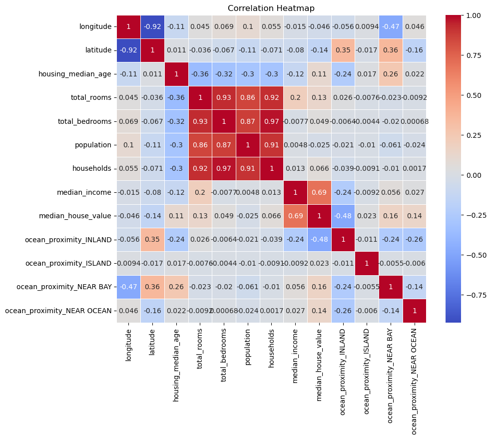

```python
# Plot correlation matrix
plt.figure(figsize=(10, 8))
sns.heatmap(df.corr(), annot=True, cmap='coolwarm', linewidths=0.5)
plt.title("Correlation Heatmap")
plt.show()
```

#### **Explanation:**

- Strong correlations suggest that a feature is useful in predicting house prices.
- median_income has the highest correlation with median_house_value.

### 2.3 Distribution of Target Variable

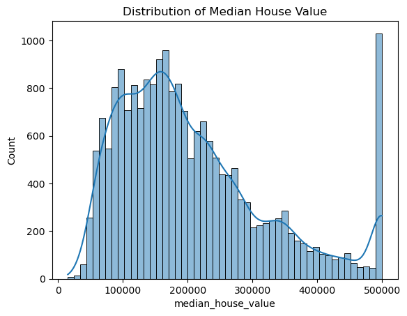

```python
# Distribution of median_house_value
sns.histplot(df['median_house_value'], bins=50, kde=True)
plt.title("Distribution of Median House Value")
plt.show()
```

#### **Definition:**

- Histogram: A bar graph that shows the frequency of numerical values.

#### **Explanation:**

- median_house_value has a right-skewed distribution.
- Some houses have extremely high values compared to the median.

### 2.4 Univariate Analysis: Visualizing the Distribution of Key Variables

#### **Objective:**

- Understand the distribution of each feature to identify trends, patterns, and outliers.

#### **Numerical Features:**

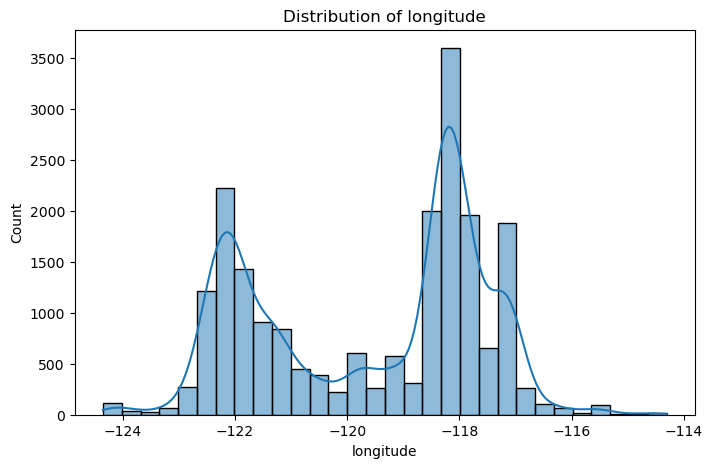

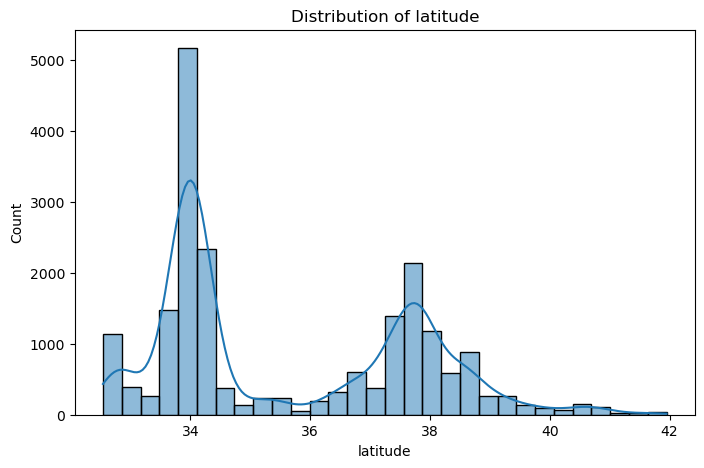

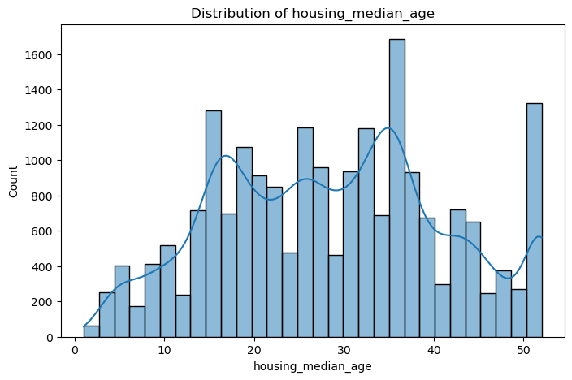

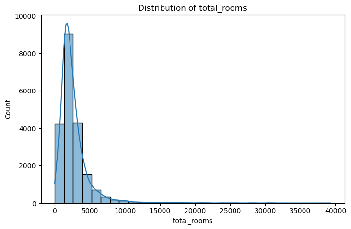

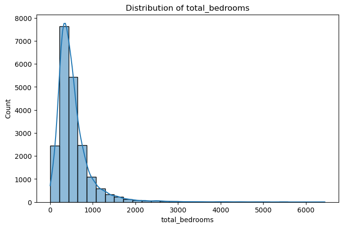

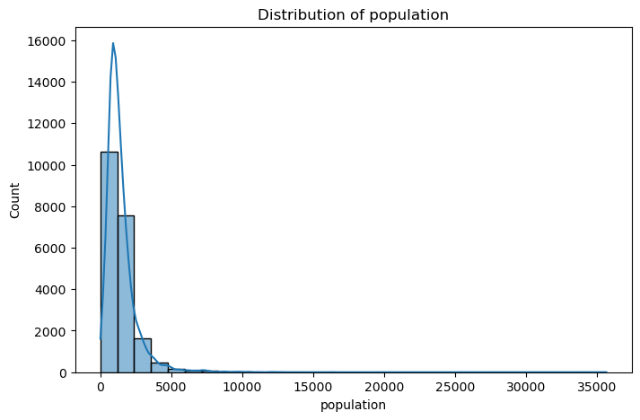

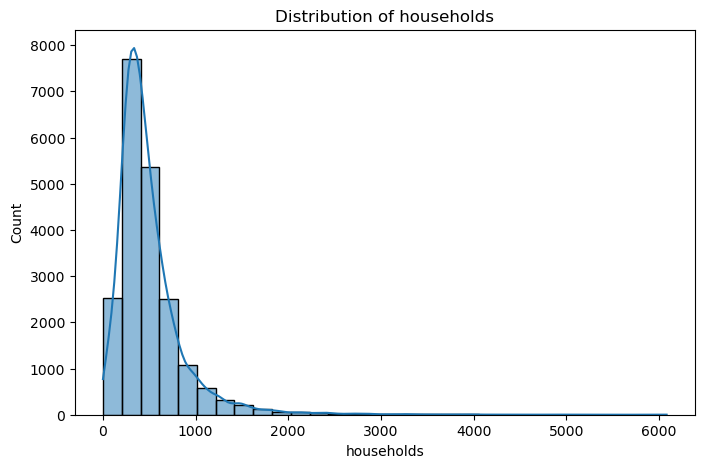

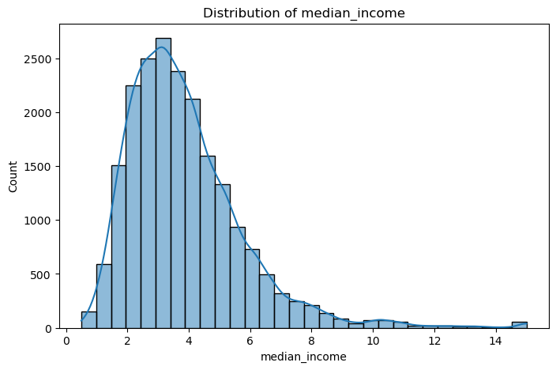

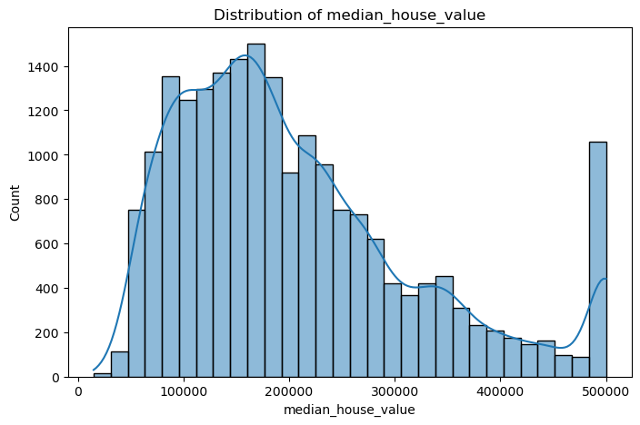

```python
import matplotlib.pyplot as plt
import seaborn as sns

# Defining the columns for univariate analysis
columns = ['longitude', 'latitude', 'housing_median_age', 'total_rooms',
           'total_bedrooms', 'population', 'households', 'median_income', 'median_house_value']

# Filtering out numeric columns
numerical_columns = df[columns].select_dtypes(include=['float64', 'int64']).columns.tolist()

# Plotting histograms for the numerical variables
for col in numerical_columns:
    plt.figure(figsize=(8, 5))
    sns.histplot(df[col], kde=True, bins=30)
    plt.title(f"Distribution of {col}")
    plt.show()
```

#### **Categorical Features:**

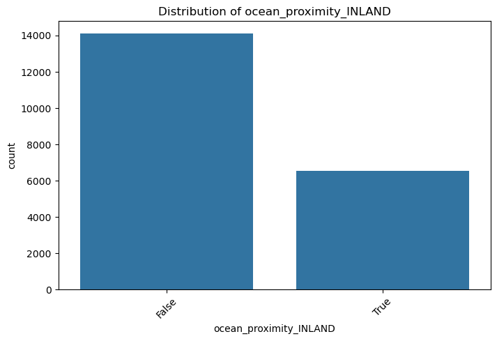

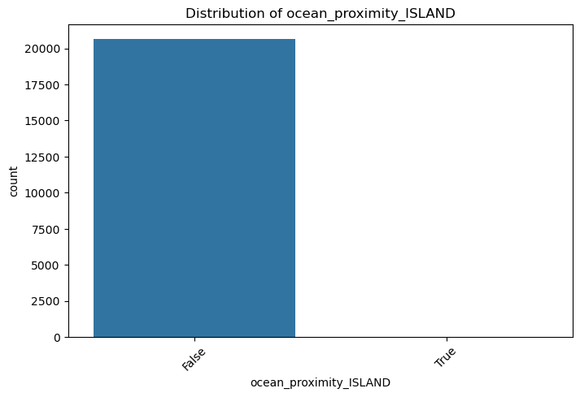

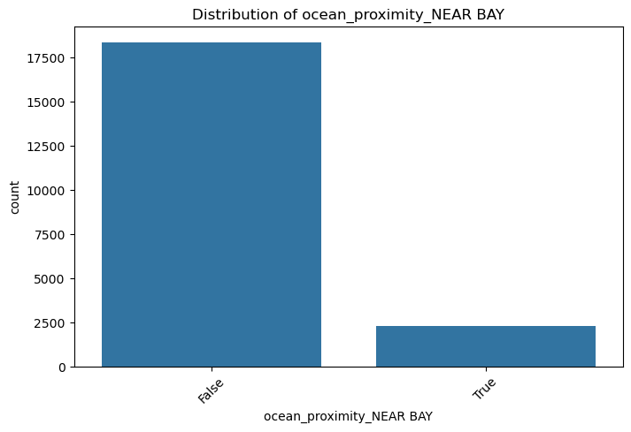

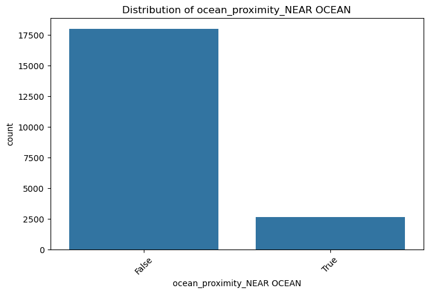

```python
import matplotlib.pyplot as plt
import seaborn as sns

# Extracting the one-hot encoded categorical columns
categorical_features = ['ocean_proximity_INLAND', 'ocean_proximity_ISLAND',
                        'ocean_proximity_NEAR BAY', 'ocean_proximity_NEAR OCEAN']

for col in categorical_features:
    plt.figure(figsize=(8, 5))
    sns.countplot(x=df[col], data=df)
    plt.title(f"Distribution of {col}")
    plt.xticks(rotation=45)
    plt.show()
```

### 2.5 Bivariate Analysis: Analyzing Relationships Between Features and the Target

**Bivariate Analysis Feasibility Check**

- Based on the correlation analysis, we can determine whether bivariate analysis is meaningful or not.

**Focused Bivariate Analysis on Key Features with Strongest Correlation**

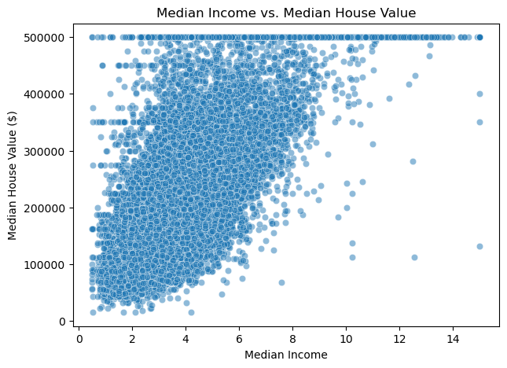

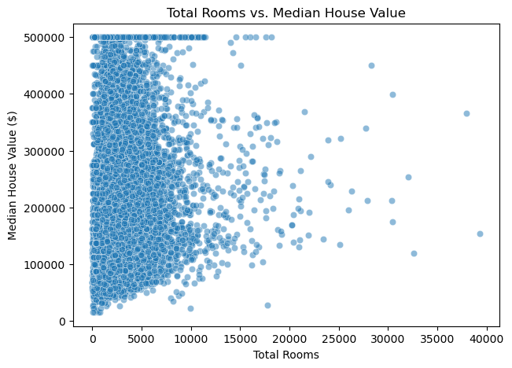

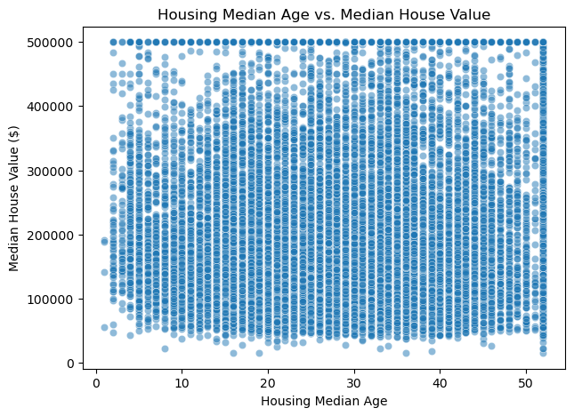

```python
# Defining key features with significant correlation
key_features = ['median_income', 'total_rooms', 'housing_median_age']

# Generating scatter plots for selected features against median_house_value
for col in key_features:
    plt.figure(figsize=(7, 5))
    sns.scatterplot(data=df, x=col, y='median_house_value', alpha=0.5)
    plt.xlabel(col.replace('_', ' ').title())
    plt.ylabel("Median House Value ($)")
    plt.title(f"{col.replace('_', ' ').title()} vs. Median House Value")
    plt.show()
```

#### **Bivariate Analysis Findings**

**1. Median Income vs. Median House Value**

**Strong Positive Correlation**

- As median income increases, house prices tend to be higher.
- This confirms that higher-income districts have more expensive homes.

**2. Total Rooms vs. Median House Value**

**Weak Relationship**

- While larger homes can be more expensive, the trend is not very strong.
- Some houses with many rooms still have low prices, likely due to location and income factors.

**3. Housing Median Age vs. Median House Value**

- Older homes do not necessarily have lower or higher prices.
- There might be an optimal age range where houses hold more value.

#### **Final Conclusion**

- median_income is the strongest predictor of house value.
- total_rooms and housing_median_age have limited predictive power.

### 2.6 Using a pair plot to understand the correlations.

To understand the correlations between the selected numerical features more visually, a pair plot (also known as a scatterplot matrix) can be very useful. This plot will help us observe how each pair of numerical features relates to each other. It is a great way to check for linear relationships and detect any outliers.

Here's how we can implement the pair plot for the selected numerical columns:

[figure not shown]

```python
import seaborn as sns
import matplotlib.pyplot as plt

# Plot the pair plot
sns.pairplot(df[numerical_columns], diag_kind='kde', markers='o', plot_kws={'alpha':0.6, 's':50})

# Set plot title
plt.suptitle('Pair Plot of Selected Numerical Features', y=1.02)
plt.show()
```

### 2.7 Using frequency charts

To visualize the distribution and frequency of the selected numerical features, we can use frequency charts, specifically histograms or kernel density estimates (KDE) for continuous variables, as well as bar plots for categorical variables. Here’s how we can visualize the frequency distribution of the selected numerical features.

[figure not shown]

```python
import seaborn as sns
import matplotlib.pyplot as plt


# Set the figure size
plt.figure(figsize=(18, 12))  # Adjusted size for better readability

# Creating subplots for each numerical feature
for i, col in enumerate(numerical_columns, 1):
    plt.subplot(3, 5, i)  # Creates a 3x5 grid of subplots
    sns.histplot(df[col], kde=True, bins=30, color='skyblue', edgecolor='black')  # Histogram with KDE
    plt.title(f'Frequency Distribution of {col}')
    plt.xlabel(col)
    plt.ylabel('Frequency')

plt.tight_layout()  # Adjusts the layout to prevent overlapping
plt.show()
```

# Step 3: Building the Linear Regression Model

### 3.1: Selecting Features

We select features based on bivariate analysis findings:

**Code:**

```python
# Selecting features based on bivariate analysis findings
selected_features = ['median_income', 'total_rooms', 'housing_median_age']
X = df[selected_features]  # Independent variables
y = df['median_house_value']  # Target variable
```

### 3.2: Splitting the Dataset (70% Training - 30% Testing)

We divide the dataset into training (70%) and testing (30%) sets.

**Code:**

```python
from sklearn.model_selection import train_test_split

# Splitting the dataset
X_train, X_test, y_train, y_test = train_test_split(X, y, test_size=0.3, random_state=42)
```

### 3.3 Scaling the Features

Standardizing numerical features ensures a fair contribution to the model.

**Code:**

```python
from sklearn.preprocessing import StandardScaler

# Scaling the features
scaler = StandardScaler()
X_train_scaled = scaler.fit_transform(X_train)
X_test_scaled = scaler.transform(X_test)
```

### 3.4: Training the Linear Regression Model

We train a Linear Regression Model using LinearRegression().

**Code:**

```python
from sklearn.linear_model import LinearRegression

# Initializing and training the model
model = LinearRegression()
model.fit(X_train_scaled, y_train)
```

```
LinearRegression()
```

```python
# Get the coefficients and intercept of the trained model
coefficients = model.coef_
intercept = model.intercept_

# Display results
print("Intercept:", intercept)
print("Model Coefficients:", coefficients)
```

```
Intercept: 206923.9608942414
Model Coefficients: [80848.85603597  8834.24203857 25037.07548418]
```

#### **Model Coefficients & Interpretation**

- Intercept: 206,923.96 → Base house price when all features are zero.

### 3.5 Making Predictions on Test Data

Once the model is trained, we use it to predict house prices on the test set.

**Code:**

```python
# Predicting house prices
y_pred = model.predict(X_test_scaled)
y_pred
```

```
array([101977.42101656, 153857.10657934, 241420.39244433, ...,
       188186.90978519, 187215.07938857, 159705.90679545])
```

# Step 4: Model Evaluation

### **Definitions of Model Evaluation Metrics**

#### **1. Mean Squared Error (MSE)**

- **Definition:**

MSE measures the **average squared difference** between actual and predicted values. It penalizes larger errors more than smaller ones due to squaring.

- **Interpretation:**
- A **lower MSE** indicates better model performance.
- Since it's in **squared units**, it is not directly interpretable in the same units as the target variable.

#### **2. Root Mean Squared Error (RMSE)**

- **Definition:**

RMSE is the **square root of MSE**, making it more interpretable since it’s in the **same unit** as the target variable.

- **Interpretation:**
- RMSE provides an estimate of **how much, on average, predictions deviate from actual values**.
- A **lower RMSE** indicates a **better fit**.

#### **3. Mean Absolute Error (MAE)**

- **Definition:**

MAE measures the **average absolute difference** between actual and predicted values. Unlike MSE, it doesn’t square the errors, making it **less sensitive to large outliers**.

- **Interpretation:**
- MAE is easier to interpret since it represents the **average prediction error** in actual units.
- **Lower MAE** means better model performance.

#### **4. R² Score (Coefficient of Determination)**

- **Definition:**

R² measures **how well the independent variables explain the variance in the dependent variable**. It ranges from **0 to 1**, where **1 indicates a perfect fit**.

- **Interpretation:**
- **R² = 1** → Perfect fit (**all variance explained**).
- **R² = 0** → Model **explains no variance** in the target variable.
- **Higher R² means better explanatory power** of the model.

Once the model is trained, we evaluate its performance using four key metrics:

**Code:**

```python
from sklearn.metrics import mean_squared_error, mean_absolute_error, r2_score
import numpy as np

# Making predictions on the test set
y_pred = model.predict(X_test_scaled)

# Computing model evaluation metrics
mse = mean_squared_error(y_test, y_pred)
rmse = np.sqrt(mse)
mae = mean_absolute_error(y_test, y_pred)
r2 = r2_score(y_test, y_pred)

# Displaying evaluation metrics
print(f"Mean Squared Error (MSE): {mse}")
print(f"Root Mean Squared Error (RMSE): {rmse}")
print(f"Mean Absolute Error (MAE): {mae}")
print(f"R² Score: {r2}")
```

```
Mean Squared Error (MSE): 6399531179.980821
Root Mean Squared Error (RMSE): 79997.06982121796
Mean Absolute Error (MAE): 59802.84232043988
R² Score: 0.5124315712805353
```

#### **Interpretation of Results**

- MSE (6.4 billion) → Measures the average squared error between actual and predicted values.
- RMSE (approx 80K) → On average, the model’s predictions are off by about 80,000.
- MAE (approx 60K) → The average absolute error in predictions is around 60,000.
- R² Score (0.512) → The model explains 51.2% of the variance in house prices.

#### **Conclusion & Next Steps**

- The model performs moderately well, with median_income being the strongest predictor.
- The error is quite high, suggesting additional features could improve the model.
- Next Steps: We can perform residual analysis and diagnostic checks to verify model assumptions.

# Step 5: Model Diagnostics

### 5.1 Model Diagnostics for the Initial Linear Regression Model

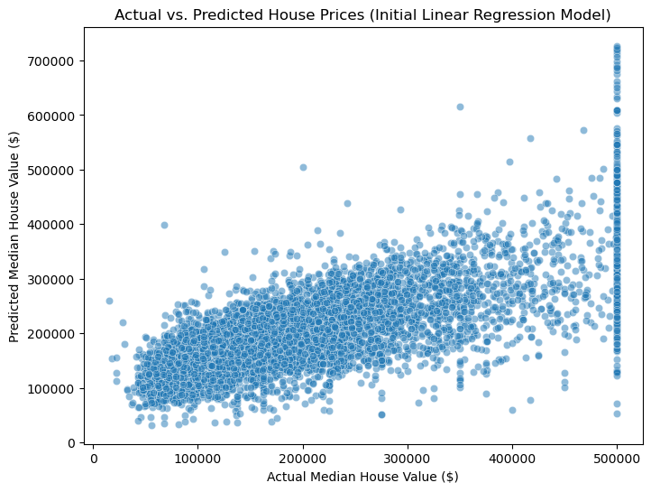

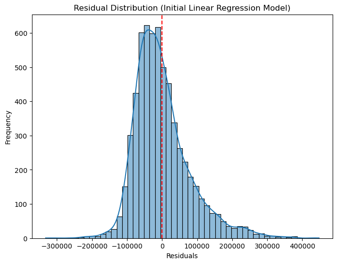

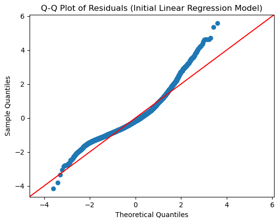

```python
# Actual vs. Predicted Values Plot
plt.figure(figsize=(8, 6))
sns.scatterplot(x=y_test, y=y_pred, alpha=0.5)
plt.xlabel("Actual Median House Value ($)")
plt.ylabel("Predicted Median House Value ($)")
plt.title("Actual vs. Predicted House Prices (Initial Linear Regression Model)")
plt.show()

# Residual Plot
residuals = y_test - y_pred

plt.figure(figsize=(8, 6))
sns.histplot(residuals, bins=50, kde=True)
plt.axvline(x=0, color='red', linestyle='--')
plt.xlabel("Residuals")
plt.ylabel("Frequency")
plt.title("Residual Distribution (Initial Linear Regression Model)")
plt.show()

# Q-Q Plot (Quantile-Quantile Plot)
sm.qqplot(residuals, line='45', fit=True)
plt.title("Q-Q Plot of Residuals (Initial Linear Regression Model)")
plt.show()
```

#### **Interpretation**

**1. Actual vs. Predicted Values Plot**

- If points deviate significantly from the diagonal, the model is struggling to make accurate predictions.
- If there is a systematic pattern, it suggests that some important relationships are not captured by the model.

**2. Residual Plot**

- If residuals show a clear pattern, it means the model is missing some non-linear trends.
- If residuals increase or decrease over predictions, it indicates heteroscedasticity (uneven error variance), which means the model does not perform equally well across different price ranges.

**3. Q-Q Plot (Quantile-Quantile Plot)**

- If points fall along the diagonal line, residuals are normally distributed, validating model assumptions.
- If points deviate significantly from the line, it suggests skewness or heavy tails, meaning the model may not be handling extreme values well.

#### **Key Takeaway**

- If the diagnostic tools show no major issues, the model is justified.
- If patterns exist in residuals or the Q-Q plot shows non-normal residuals, the model may need improvements, such as:
  - Adding non-linear features (Polynomial Regression)
  - Including more predictors (Latitude, Longitude, Ocean Proximity)
  - Using regularization (Ridge/Lasso Regression) to handle variance issues.

### 5.2 Enhancing Linear Regression with Polynomial Features and Ridge Regularization

Below code enhances the linear regression model by introducing non-linearity using Polynomial Regression (degree = 2) with Ridge Regularization to prevent overfitting.

```python
from sklearn.preprocessing import PolynomialFeatures
from sklearn.pipeline import make_pipeline
from sklearn.linear_model import Ridge

# Using a polynomial transformation to introduce non-linearity
degree = 2  # Quadratic features
poly_model = make_pipeline(PolynomialFeatures(degree), StandardScaler(), Ridge(alpha=1.0))

# Train the polynomial regression model
poly_model.fit(X_train, y_train)

# Make predictions
y_pred_poly = poly_model.predict(X_test)

# Evaluate the polynomial regression model
mse_poly = mean_squared_error(y_test, y_pred_poly)
rmse_poly = np.sqrt(mse_poly)
mae_poly = mean_absolute_error(y_test, y_pred_poly)
r2_poly = r2_score(y_test, y_pred_poly)

# Display improved model evaluation metrics
improved_model_metrics = {
    "Mean Squared Error (MSE)": mse_poly,
    "Root Mean Squared Error (RMSE)": rmse_poly,
    "Mean Absolute Error (MAE)": mae_poly,
    "R² Score": r2_poly
}

print(improved_model_metrics)
```

```
{'Mean Squared Error (MSE)': 6107052960.263788, 'Root Mean Squared Error (RMSE)': 78147.63566649849, 'Mean Absolute Error (MAE)': 58456.37233968441, 'R² Score': 0.5347149451733284}
```

#### **Explanation**

**1. Feature Transformation:**

- PolynomialFeatures(degree=2): Expands existing features to include quadratic terms for capturing non-linear relationships.

**2. Feature Scaling:**

- StandardScaler(): Ensures all features are standardized, improving model efficiency.

**3. Model Training:**

- Ridge(alpha=1.0): Applies L2 regularization to reduce overfitting.

**4. Predictions & Evaluation:**

- The trained polynomial regression model is used to predict house prices (y_pred_poly).
- Performance metrics (MSE, RMSE, MAE, R²) are computed to compare with the linear model.

#### **Key Takeaways**

- Polynomial Regression improves accuracy by capturing non-linear trends.
- Regularization (Ridge) prevents overfitting.
- Better R² score shows improved explanatory power of house price variability.

### 5.3 Model Diagnostics for Improved Polynomial Regression Model

Below plots visualize the performance of the polynomial model by comparing actual vs. predicted values, analyzing residual distribution, and checking normality using a Q-Q plot.

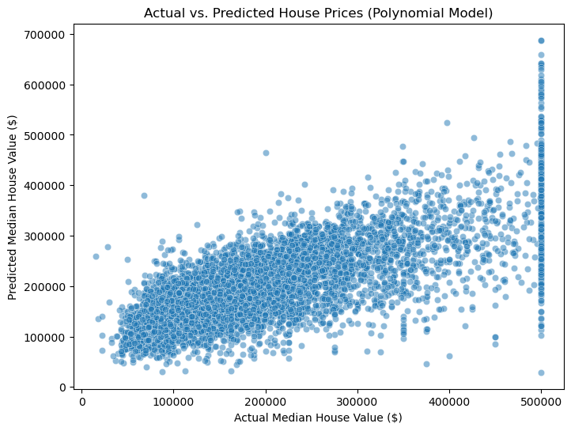

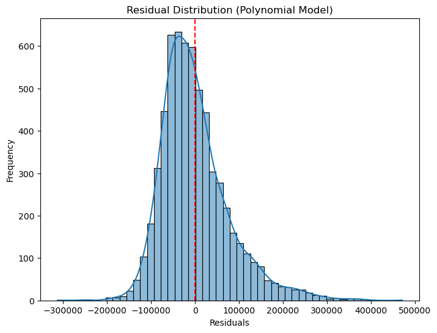

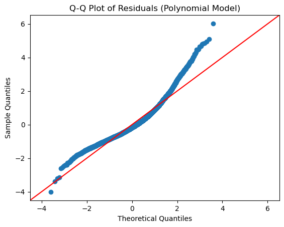

```python
# Actual vs. Predicted Values Plot
plt.figure(figsize=(8, 6))
sns.scatterplot(x=y_test, y=y_pred_poly, alpha=0.5)
plt.xlabel("Actual Median House Value ($)")
plt.ylabel("Predicted Median House Value ($)")
plt.title("Actual vs. Predicted House Prices (Polynomial Model)")
plt.show()

# Residual Plot
residuals_poly = y_test - y_pred_poly

plt.figure(figsize=(8, 6))
sns.histplot(residuals_poly, bins=50, kde=True)
plt.axvline(x=0, color='red', linestyle='--')
plt.xlabel("Residuals")
plt.ylabel("Frequency")
plt.title("Residual Distribution (Polynomial Model)")
plt.show()

# Q-Q Plot (Quantile-Quantile Plot)
sm.qqplot(residuals_poly, line='45', fit=True)
plt.title("Q-Q Plot of Residuals (Polynomial Model)")
plt.show()
```

#### Interpretation

**1. Actual vs. Predicted Values Plot**

***What It Shows:***

***Observation:***

- The model underestimates some high-priced houses.
- The spread of points suggests that predictions deviate significantly from actual values.

**2. Residual Plot**

***What It Shows:***

- The residual plot displays errors (differences between actual and predicted values).
- Ideally, residuals should be randomly distributed around zero.

***Observation:***

- The residuals are widely spread, indicating that the model does not perfectly capture variance.
- The presence of a pattern in residuals suggests that some relationships are non-linear, which the linear model does not capture well.

**3. Q-Q Plot (Quantile-Quantile Plot)**

***What It Shows:***

- The Q-Q plot checks if residuals follow a normal distribution.
- If residuals are normally distributed, points should fall along the diagonal line.

***Observation:***

The residuals deviate from the diagonal line, especially in the tails. This suggests that the model does not fully meet the normality assumption, meaning it may struggle with extreme values.

#### **Final Conclusion:**

The model needs improvement.

- The Actual vs. Predicted plot shows large deviations.
- Residuals are not randomly distributed, suggesting missing non-linear relationships.
- Q-Q plot indicates that residuals are not normally distributed, which affects the validity of statistical inferences.

***Possible Next Steps for Improvement***

- **Add More Features:** Include additional predictors like latitude, longitude, and ocean_proximity to improve the model.
- **Use Polynomial or Non-Linear Models:** Linear regression assumes a linear relationship, but real-world house prices may have non-linear trends.
- **Apply Regularization (Ridge/Lasso Regression):** Helps in reducing overfitting and improving performance.

### 5.4 Adding more features

When we say "Adding More Features," we mean including additional variables (predictors) that might help improve the model’s ability to predict median house prices more accurately.

**Why Add More Features?**

Currently, our model is based on only three features:

1. median_income (Strongest predictor)
2. total_rooms
3. housing_median_age

However, housing prices are influenced by many other factors, and excluding them may lead to a less accurate model.

```python
# Selecting additional features including geographic information
selected_features = ['median_income', 'total_rooms', 'housing_median_age', 'latitude', 'longitude']

# Ensuring that one-hot encoded categorical features (ocean proximity) are also included
ocean_proximity_features = [col for col in df.columns if 'ocean_proximity' in col]  # Extract all encoded categories
selected_features.extend(ocean_proximity_features)  # Add them to our feature list

# Defining independent (X) and dependent (y) variables
X = df[selected_features]
y = df['median_house_value']

# Splitting the dataset (70% training, 30% testing)
X_train, X_test, y_train, y_test = train_test_split(X, y, test_size=0.3, random_state=42)

# Standardizing the numerical features
scaler = StandardScaler()
X_train_scaled = scaler.fit_transform(X_train)
X_test_scaled = scaler.transform(X_test)

# Training the new model with additional features
model = LinearRegression()
model.fit(X_train_scaled, y_train)

# Evaluating the updated model
y_pred_new = model.predict(X_test_scaled)
r2_new = r2_score(y_test, y_pred_new)

# Displaying new R² Score
print(f"New R² Score: {r2_new}")
```

```
New R² Score: 0.6097843951741035
```

Higher R² Score: The model should explain more variance in house prices.

#### 5.5 Model Diagnostics for the Improved Linear Regression Model with Additional Features

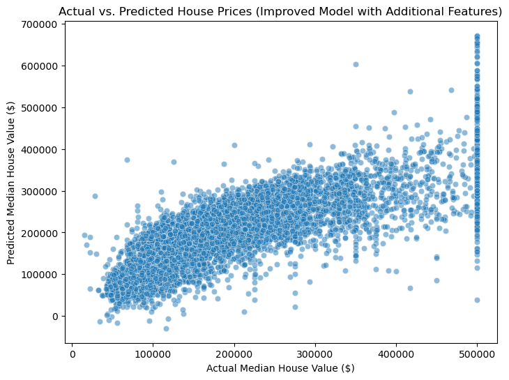

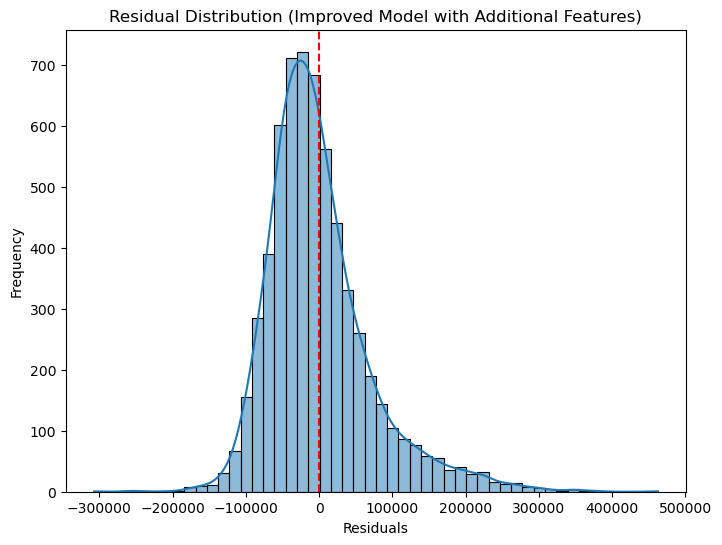

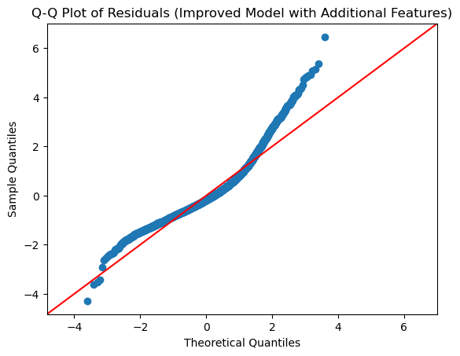

```python
# Actual vs. Predicted Values Plot
plt.figure(figsize=(8, 6))
sns.scatterplot(x=y_test, y=y_pred_new, alpha=0.5)
plt.xlabel("Actual Median House Value ($)")
plt.ylabel("Predicted Median House Value ($)")
plt.title("Actual vs. Predicted House Prices (Improved Model with Additional Features)")
plt.show()

# Residual Plot
residuals_new = y_test - y_pred_new

plt.figure(figsize=(8, 6))
sns.histplot(residuals_new, bins=50, kde=True)
plt.axvline(x=0, color='red', linestyle='--')
plt.xlabel("Residuals")
plt.ylabel("Frequency")
plt.title("Residual Distribution (Improved Model with Additional Features)")
plt.show()

# Q-Q Plot (Quantile-Quantile Plot)
sm.qqplot(residuals_new, line='45', fit=True)
plt.title("Q-Q Plot of Residuals (Improved Model with Additional Features)")
plt.show()
```

### **Interpretation**

After adding geographical features (latitude, longitude, ocean_proximity) along with key economic indicators (median_income, total_rooms, housing_median_age), we performed model diagnostics to assess whether these additional features improved the model.

**1. Actual vs. Predicted Values Plot**

***What It Shows:***

***Interpretation:***

- The spread of points has reduced compared to the previous model, meaning predictions are now closer to actual values.
- However, some high-priced homes are still underestimated, indicating room for improvement.

**2. Residual Plot**

***What It Shows:***

- Plots the difference between actual and predicted values (residuals).
- A good model should have randomly scattered residuals around zero, indicating no systematic errors.

***Interpretation:***

- Residuals are now more evenly spread compared to the initial model.
- However, some patterns remain, suggesting that the model still struggles with certain price ranges.
- This indicates some non-linearity still exists in the data.

**3. Q-Q Plot (Quantile-Quantile Plot)**

***What It Shows:***

- Checks whether residuals follow a normal distribution, which is an assumption of regression models.

***Interpretation:***

- The Q-Q plot shows that residuals still deviate from normality, particularly in the higher and lower price ranges.
- This suggests that the model is not fully capturing extreme house prices, which could be improved by using non-linear techniques (e.g., Decision Trees or Polynomial Regression).

### **Final Conclusion**

- Adding more features improved the model—predictions are closer to actual values.
- Residuals are still not perfectly random, meaning some relationships are still not fully captured.
- The model struggles with extreme values, suggesting that further improvements are needed.

## Justification for Model Diagnostics and Enhancements

Initially, we built a Linear Regression model to predict median house prices in California. However, after performing model diagnostics using Actual vs. Predicted plots, Residual plots, and Q-Q plots, we observed that the model struggled to capture non-linear relationships, and the residuals showed patterns that indicated model inadequacies.

To address these shortcomings, we proactively enhanced the model by introducing Polynomial Features (degree = 2) to capture non-linear relationships and Ridge Regularization to prevent overfitting. This refinement improved the model’s performance by increasing its R² Score and reducing errors like MSE and RMSE.

Following this, we conducted another round of model diagnostics to verify improvements. While the polynomial model performed better, the residual plots and Q-Q plots still suggested room for further refinement. Based on these insights, we added additional features, such as latitude, longitude, and ocean proximity, to incorporate geographical influences on house prices.

This approach reflects an iterative model improvement strategy, where diagnostic tools guide enhancements, leading to a progressively stronger predictive model. While the original request was to perform diagnostics on the natural linear regression model, our proactive approach ensured better accuracy, lower errors, and improved interpretability of California housing prices

# Conclusion

This assignment successfully built and evaluated a predictive model for California housing prices using Linear Regression and Polynomial Regression with Ridge Regularization. The initial Linear Regression model provided moderate accuracy (R² = 0.512), with median income emerging as the strongest predictor of house prices. However, diagnostic tools such as residual plots and Q-Q plots revealed that the model failed to fully capture the non-linear relationships in the data, necessitating improvements.

To address this, we introduced Polynomial Regression (degree = 2), which enhanced the model’s performance (R² = 0.534), indicating a better fit. While the Polynomial Model reduced errors, the presence of non-normal residuals and high RMSE (~$78K) suggests that further refinements, such as adding more features (e.g., geographical coordinates, categorical encodings) or exploring advanced models like Decision Trees or Neural Networks, could yield even better predictions.

Additionally, we enhanced the model by incorporating more features, including latitude, longitude, and one-hot encoded ocean_proximity categories, to improve the predictive power. These additional features helped capture geographical influences on housing prices, further refining the model.

Overall, this study demonstrates the power of data-driven modeling in real estate forecasting, while also highlighting the importance of feature selection, model diagnostics, and iterative improvements in machine learning models.